# Hayrettin İlbey GÜNGÖR 2018402183

# Homework 2

# 1)Introduction

In this homework, I will try to forecast the sales of UGS for every quarter in 2007 by using trend, seasonility and variables.

# 2)Installing Libraries and Data Gathering

```r
install.packages('readxl')
install.packages('RcppRoll')
install.packages('data.table')
install.packages('ggplot2')
install.packages('lubridate')
install.packages('scales')
install.packages('forecast')
install.packages('GGally')
install.packages('dplyr')
install.packages('corrplot')
install.packages('ggcorrplot')
install.packages('zoo')
```

```r
library(readxl)
library(RcppRoll)
library(data.table)
library(ggplot2)
library(lubridate)
library(scales)
library(forecast)
library(GGally)
library(dplyr)
library(corrplot)
library(ggcorrplot)
library(zoo)
```

```r
Data <- read.csv('data/IE360_Spring22_HW2_data.csv',colClasses=c('character',rep('numeric',10)))
colnames(Data) <- c("Quarters", "UGS", "RNUV","NLPG","PU","PG","NUGV","NDGV","GNPA","GNPC","GNPT")
Data$Quarters <- as.Date(as.yearqtr(Data$Quarters, format = "%Y_Q%q"))
Training <- Data[c(1:28),]
Forecast <- Data[c(29,30,31,32),]
Training <- data.table(Training)
Forecast <- data.table(Forecast)
head(Training)
str(Training)
```

A data.table: 6 × 11

| Quarters <date> | UGS <dbl> | RNUV <dbl> | NLPG <dbl> | PU <dbl> | PG <dbl> | NUGV <dbl> | NDGV <dbl> | GNPA <dbl> | GNPC <dbl> | GNPT <dbl> |
| --- | --- | --- | --- | --- | --- | --- | --- | --- | --- | --- |
| 2000-01-01 | 1128971 | 0.0146 | 940000 | 469.03 | 355.69 | 4647500 | 281.9853 | 1040173 | 3483132 | 18022686 |
| 2000-04-01 | 1199569 | 0.0205 | 941000 | 459.42 | 344.58 | 4742876 | 284.0813 | 1760460 | 4525451 | 21797130 |
| 2000-07-01 | 1370167 | 0.0207 | 943500 | 439.98 | 327.21 | 4840931 | 286.7169 | 6974808 | 5915204 | 30050207 |
| 2000-10-01 | 1127548 | 0.0163 | 948000 | 402.08 | 300.67 | 4919685 | 288.3137 | 3267125 | 4929778 | 24480153 |
| 2001-01-01 | 1033918 | 0.0071 | 950000 | 411.58 | 305.75 | 4954754 | 287.6237 | 1004528 | 3418387 | 15832648 |
| 2001-04-01 | 1019754 | 0.0051 | 955000 | 520.39 | 374.78 | 4980204 | 287.8814 | 1449357 | 4359831 | 20296918 |

```
Classes ‘data.table’ and 'data.frame':	28 obs. of  11 variables:
 $ Quarters: Date, format: "2000-01-01" "2000-04-01" ...
 $ UGS     : num  1128971 1199569 1370167 1127548 1033918 ...
 $ RNUV    : num  0.0146 0.0205 0.0207 0.0163 0.0071 0.0051 0.0041 0.0048 0.0012 0.0032 ...
 $ NLPG    : num  940000 941000 943500 948000 950000 ...
 $ PU      : num  469 459 440 402 412 ...
 $ PG      : num  356 345 327 301 306 ...
 $ NUGV    : num  4647500 4742876 4840931 4919685 4954754 ...
 $ NDGV    : num  282 284 287 288 288 ...
 $ GNPA    : num  1040173 1760460 6974808 3267125 1004528 ...
 $ GNPC    : num  3483132 4525451 5915204 4929778 3418387 ...
 $ GNPT    : num  18022686 21797130 30050207 24480153 15832648 ...
 - attr(*, ".internal.selfref")=<externalptr>
```

# 3) Visualizations of Data

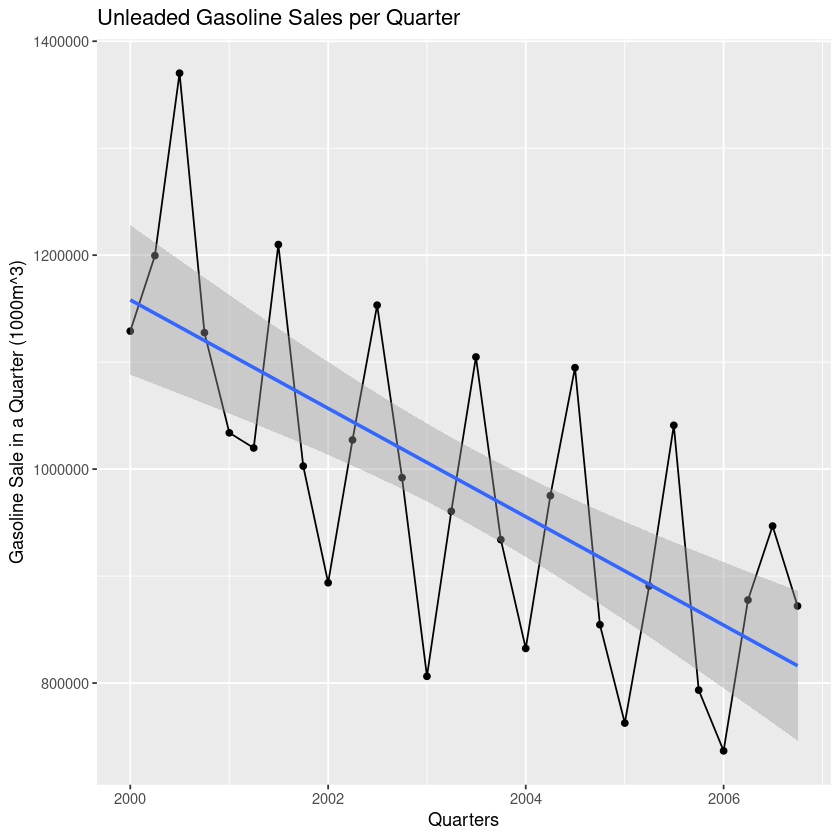

```r
ggplot(Training, aes(x=Quarters,y=UGS, group = 1)) +
geom_point() +
geom_line() +
labs(y ='Gasoline Sale in a Quarter (1000m^3)')+
ggtitle('Unleaded Gasoline Sales per Quarter')+
geom_smooth(formula = y ~ x, method = "lm",level=0.9)
```

We can clearly see that there is a seasonality which is a yearly-seasonality from the pattern of every four-quarter period.

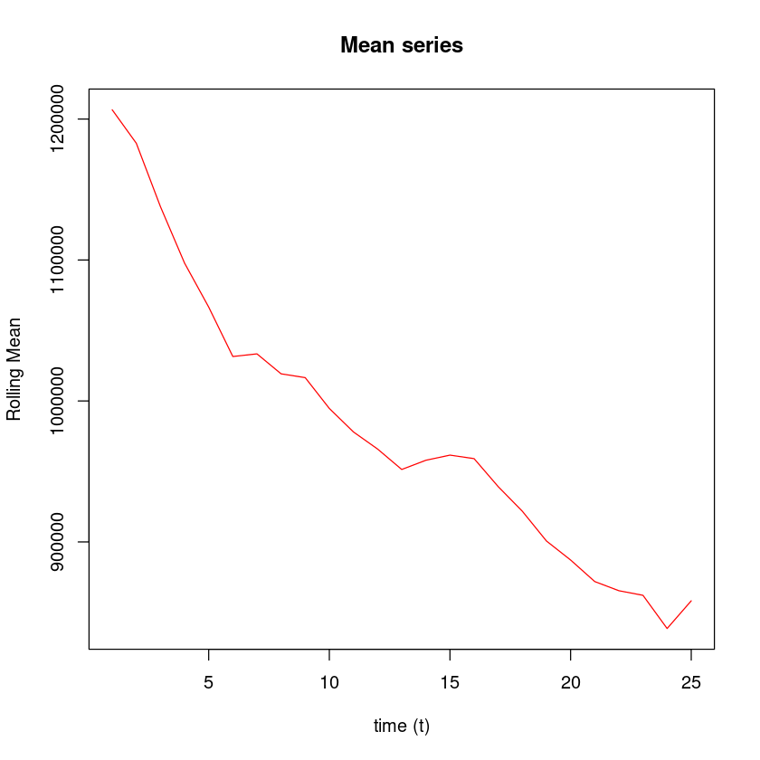

```r
mean_series=roll_mean(Training$UGS,4,align='left')
plot(mean_series,
     type='l',col='red',
     xlab = "time (t)",
     ylab = "Rolling Mean",
     main = "Mean series")
```

From the plot of mean series, it is obtained that there is a declining trend. Also, it shows us that data is not stationary because the Rolling mean changes with respect to time.

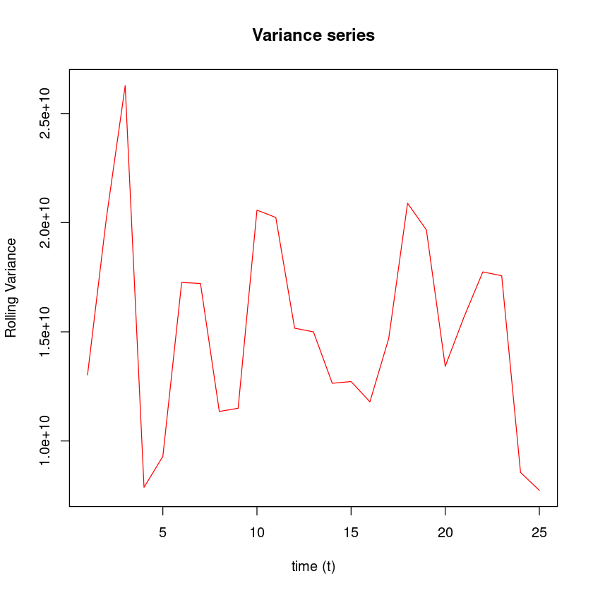

```r
var_series=roll_var(Training$UGS,4,align='left')
plot(var_series,
     type='l',col='red',
     xlab = "time (t)",
     ylab = "Rolling Variance",
     main = "Variance series")
```

In variance series, we can not obtain strong signs about the data whether it is stationary or not as the mean series.

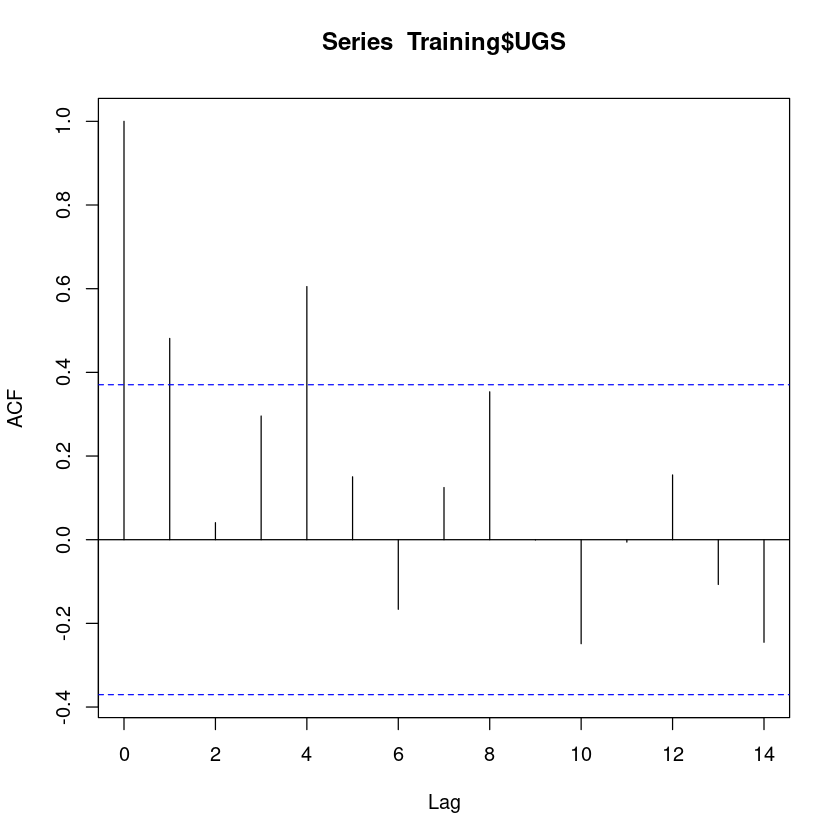

```r
acf(Training$UGS)
```

This autocorrelation graph also strengths that yearly-seasonality exists in this data. We can see it from each four-quarter period. For example multiples of 4 are higher than others. In addition, Lag 1 shows us the decreasing trend.

# 4)Making Model for Linear Regression

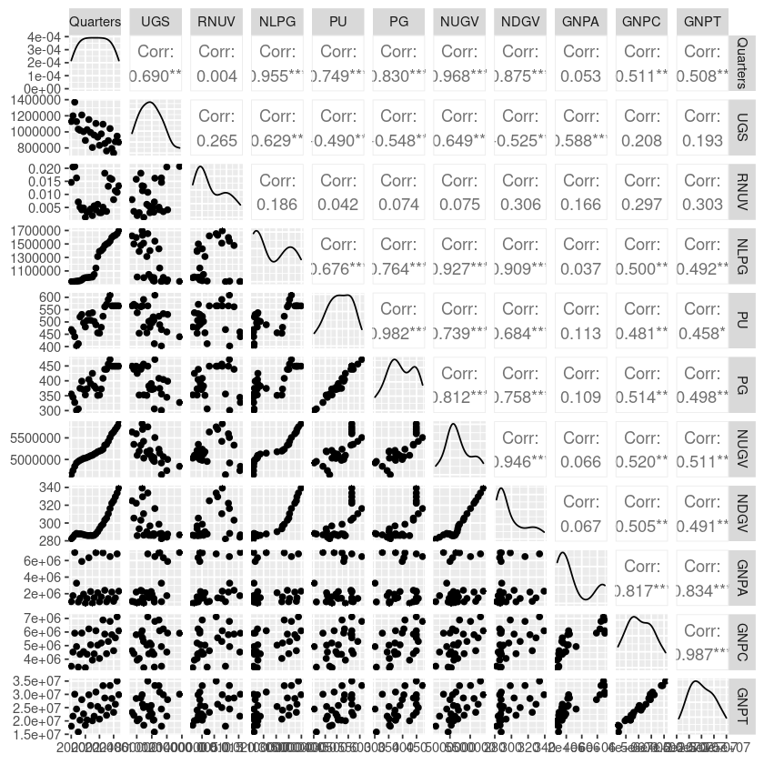

```r
ggpairs(Training)
```

To see the correlated variables with UGS, I used the ggpairs function. From output of ggpairs funtion we can see that NLPG, PU, PG, NUGV, NDGV, GNPA are correlated with UGS.

```
Call:
lm(formula = UGS ~ Quarters, data = Training)

Residuals:
    Min      1Q  Median      3Q     Max
-199873  -73453  -21971   71303  237234

Coefficients:
              Estimate Std. Error t value Pr(>|t|)
(Intercept) 2678294.56  348665.34   7.682 3.76e-08 ***
Quarters       -138.73      28.55  -4.859 4.88e-05 ***
---
Signif. codes:  0 ‘***’ 0.001 ‘**’ 0.01 ‘*’ 0.05 ‘.’ 0.1 ‘ ’ 1

Residual standard error: 111400 on 26 degrees of freedom
Multiple R-squared:  0.4759,	Adjusted R-squared:  0.4558
F-statistic: 23.61 on 1 and 26 DF,  p-value: 4.875e-05
```

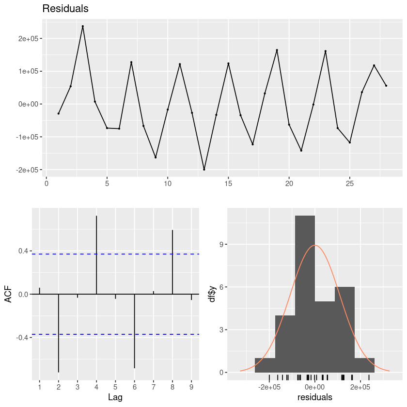

```r
Model_1 <- lm(UGS ~ Quarters, Training)
summary(Model_1)
checkresiduals(Model_1$residuals)
```

Nothing added to the model, RSE is very high.

```
Call:
lm(formula = UGS ~ trend + Quarters, data = Training)

Residuals:
    Min      1Q  Median      3Q     Max
-130962  -50165    3623   46175  186841

Coefficients:
              Estimate Std. Error t value Pr(>|t|)
(Intercept) 1510634289  285724269   5.287 1.78e-05 ***
trend         12671554    2400978   5.278 1.82e-05 ***
Quarters       -138923      26297  -5.283 1.80e-05 ***
---
Signif. codes:  0 ‘***’ 0.001 ‘**’ 0.01 ‘*’ 0.05 ‘.’ 0.1 ‘ ’ 1

Residual standard error: 78150 on 25 degrees of freedom
Multiple R-squared:  0.7521,	Adjusted R-squared:  0.7323
F-statistic: 37.92 on 2 and 25 DF,  p-value: 2.681e-08
```

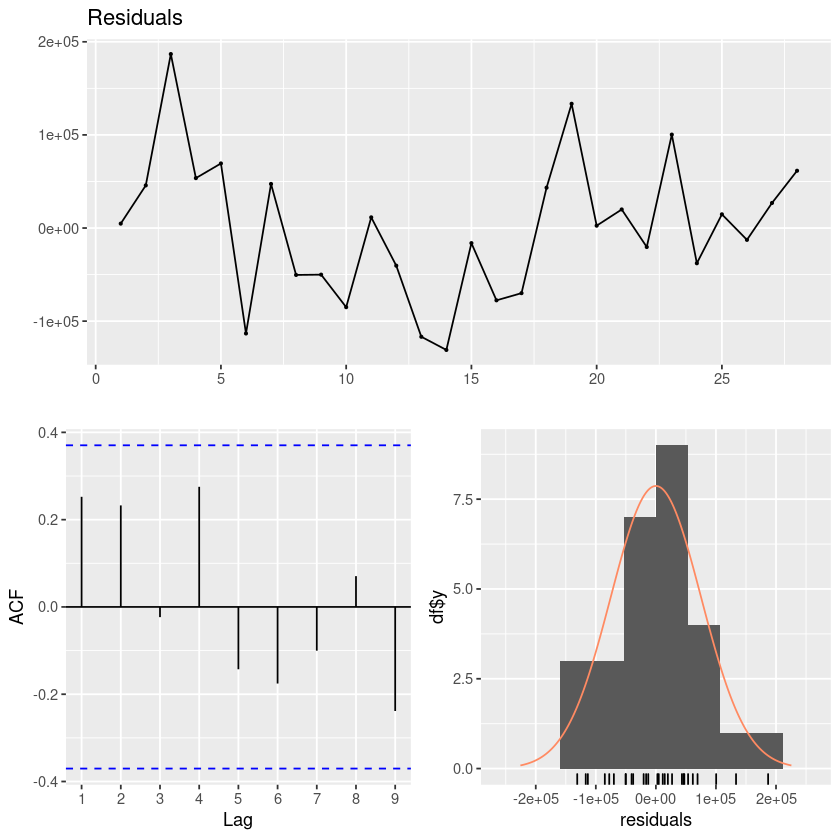

```r
Training[,trend := 1:.N ]
Model_2 <- lm(UGS ~ trend+Quarters, Training)
summary(Model_2)
checkresiduals(Model_2$residuals)
```

I added only trend to the model, RSE has decreased considerably and Adjusted R-squared values increased.

```
Call:
lm(formula = UGS ~ trend + Quarters_seasonality, data = Training)

Residuals:
   Min     1Q Median     3Q    Max
-81167 -31283  -3458  28640  94502

Coefficients:
                       Estimate Std. Error t value Pr(>|t|)
(Intercept)             1060372      23653  44.830  < 2e-16 ***
trend                    -13497       1147 -11.764 3.28e-11 ***
Quarters_seasonality10    95049      26189   3.629 0.001405 **
Quarters_seasonality4    121532      25987   4.677 0.000104 ***
Quarters_seasonality7    273618      26063  10.498 3.03e-10 ***
---
Signif. codes:  0 ‘***’ 0.001 ‘**’ 0.01 ‘*’ 0.05 ‘.’ 0.1 ‘ ’ 1

Residual standard error: 48570 on 23 degrees of freedom
Multiple R-squared:  0.9119,	Adjusted R-squared:  0.8966
F-statistic: 59.53 on 4 and 23 DF,  p-value: 8.446e-12
```

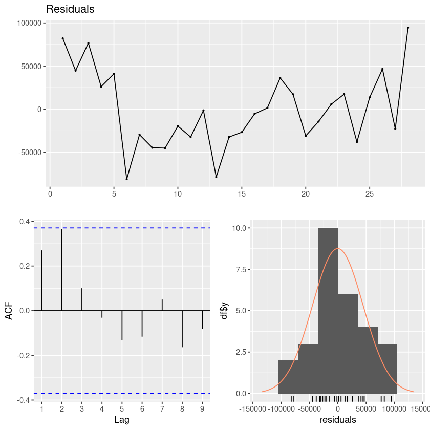

```r
Training[,trend := 1:.N ]
Training[,Quarters_seasonality:=as.character(month(Quarters))]

Model_3 <- lm(UGS ~ trend+Quarters_seasonality, Training)
summary(Model_3)
checkresiduals(Model_3$residuals)
```

I added seasonality to the model, RSE decreased, Adjusted R-squared increased again.

```
Call:
lm(formula = UGS ~ trend + NLPG + PU + PG + NUGV + NDGV + GNPA +
    Quarters_seasonality, data = Training)

Residuals:
   Min     1Q Median     3Q    Max
-67794 -10461   1987  18461  32208

Coefficients:
                         Estimate Std. Error t value Pr(>|t|)
(Intercept)             3.094e+06  8.283e+05   3.735  0.00165 **
trend                   1.514e+04  1.284e+04   1.178  0.25486
NLPG                   -2.937e-01  1.804e-01  -1.628  0.12195
PU                      2.276e+01  1.017e+03   0.022  0.98241
PG                     -1.129e+03  1.437e+03  -0.786  0.44295
NUGV                   -1.023e+00  3.343e-01  -3.061  0.00708 **
NDGV                    1.238e+04  3.581e+03   3.456  0.00302 **
GNPA                   -3.613e-02  2.764e-02  -1.307  0.20854
Quarters_seasonality10  1.607e+05  4.385e+04   3.664  0.00192 **
Quarters_seasonality4   1.463e+05  2.356e+04   6.212 9.48e-06 ***
Quarters_seasonality7   4.953e+05  1.597e+05   3.102  0.00648 **
---
Signif. codes:  0 ‘***’ 0.001 ‘**’ 0.01 ‘*’ 0.05 ‘.’ 0.1 ‘ ’ 1

Residual standard error: 29700 on 17 degrees of freedom
Multiple R-squared:  0.9757,	Adjusted R-squared:  0.9613
F-statistic: 68.12 on 10 and 17 DF,  p-value: 1.055e-11
```

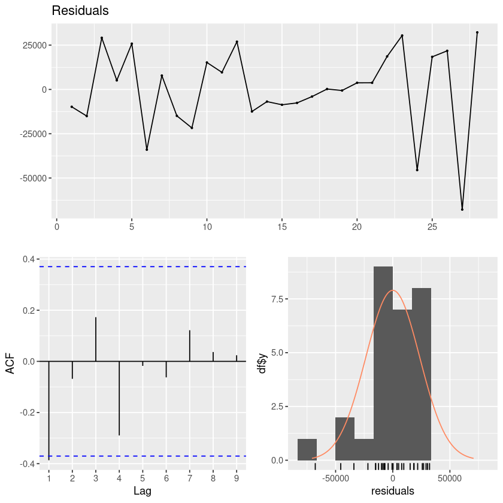

```r
Training[,trend := 1:.N ]
Training[,Quarters_seasonality:=as.character(month(Quarters))]

Model_4 <- lm(UGS ~ trend+NLPG+PU+PG+NUGV+NDGV+GNPA+Quarters_seasonality, Training)
summary(Model_4)
checkresiduals(Model_4$residuals)
```

I added the variables which have correlation with UGS, RSE decreased, Adjusted R-squared increased again. We can see that only NUGV and NDGV are correlated with UGS importantly from summary.

```
Call:
lm(formula = UGS ~ trend + PU + PG + NUGV + NDGV + GNPA + UGSlag1 +
    NUGVlag1 + NDGVlag1 + Quarters_seasonality, data = Training)

Residuals:
   Min     1Q Median     3Q    Max
-43137 -13087  -3639  12232  38402

Coefficients:
                         Estimate Std. Error t value Pr(>|t|)
(Intercept)             2.793e+06  7.373e+05   3.788   0.0020 **
trend                  -1.029e+04  8.865e+03  -1.161   0.2651
PU                     -1.031e+03  9.273e+02  -1.112   0.2849
PG                      5.189e+02  1.288e+03   0.403   0.6931
NUGV                   -4.022e-01  6.714e-01  -0.599   0.5587
NDGV                    6.280e+03  1.135e+04   0.553   0.5888
GNPA                    6.906e-03  3.487e-02   0.198   0.8458
UGSlag1                -5.507e-01  2.563e-01  -2.149   0.0496 *
NUGVlag1               -2.904e-01  6.220e-01  -0.467   0.6478
NDGVlag1                2.620e+03  1.169e+04   0.224   0.8260
Quarters_seasonality10  1.943e+05  5.019e+04   3.871   0.0017 **
Quarters_seasonality4   8.127e+04  4.132e+04   1.967   0.0694 .
Quarters_seasonality7   2.705e+05  1.948e+05   1.389   0.1866
---
Signif. codes:  0 ‘***’ 0.001 ‘**’ 0.01 ‘*’ 0.05 ‘.’ 0.1 ‘ ’ 1

Residual standard error: 29870 on 14 degrees of freedom
  (1 observation deleted due to missingness)
Multiple R-squared:  0.979,	Adjusted R-squared:  0.961
F-statistic: 54.42 on 12 and 14 DF,  p-value: 1.295e-09
```

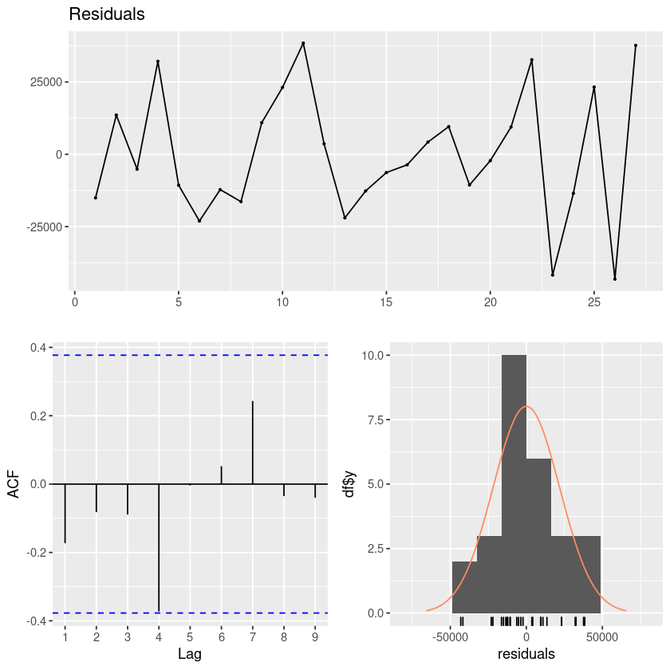

```r
Training$UGSlag1=lag(Training$UGS,1)
Training$NUGVlag1=lag(Training$NUGV,1)
Training$NDGVlag1=lag(Training$NDGV,1)
Model_5 <- lm(UGS ~ trend+PU+PG+NUGV+NDGV+GNPA+UGSlag1+NUGVlag1+NDGVlag1+Quarters_seasonality, Training)
summary(Model_5)
checkresiduals(Model_5$residuals)
```

I added lag 1 variables because there is a big autocorrelation at lag 1. RSE has increased slightly this time. also Adjusted R-squared decreased very little.

```
Call:
lm(formula = UGS ~ trend + PU + PG + NUGV + NDGV + GNPA + UGSlag1 +
    NUGVlag1 + NDGVlag1 + UGSlag5 + Quarters_seasonality, data = Training)

Residuals:
   Min     1Q Median     3Q    Max
-42557 -10404  -1557  14592  31910

Coefficients:
                         Estimate Std. Error t value Pr(>|t|)
(Intercept)             2.408e+06  1.020e+06   2.362  0.04249 *
trend                  -1.581e+04  1.326e+04  -1.193  0.26342
PU                     -2.973e+01  1.351e+03  -0.022  0.98293
PG                     -8.611e+01  1.746e+03  -0.049  0.96173
NUGV                   -1.446e+00  8.373e-01  -1.727  0.11829
NDGV                    1.649e+04  1.425e+04   1.157  0.27687
GNPA                    1.352e-02  5.907e-02   0.229  0.82409
UGSlag1                -5.646e-01  3.096e-01  -1.823  0.10155
NUGVlag1                9.375e-01  9.287e-01   1.009  0.33913
NDGVlag1               -9.668e+03  1.449e+04  -0.667  0.52141
UGSlag5                -1.447e-01  2.834e-01  -0.511  0.62198
Quarters_seasonality10  2.502e+05  7.642e+04   3.274  0.00962 **
Quarters_seasonality4   7.956e+04  7.099e+04   1.121  0.29137
Quarters_seasonality7   2.482e+05  3.277e+05   0.757  0.46824
---
Signif. codes:  0 ‘***’ 0.001 ‘**’ 0.01 ‘*’ 0.05 ‘.’ 0.1 ‘ ’ 1

Residual standard error: 29680 on 9 degrees of freedom
  (5 observations deleted due to missingness)
Multiple R-squared:  0.977,	Adjusted R-squared:  0.9438
F-statistic: 29.44 on 13 and 9 DF,  p-value: 9.167e-06
```

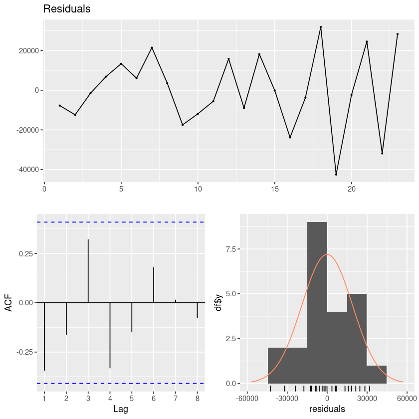

```r
Training$UGSlag5=lag(Training$UGS,5)
Training$NUGVlag5=lag(Training$NUGV,5)
Training$NDGVlag5=lag(Training$NDGV,5)
Model_6 <- lm(UGS ~ trend+PU+PG+NUGV+NDGV+GNPA+UGSlag1+NUGVlag1+NDGVlag1+UGSlag5+Quarters_seasonality, Training)
summary(Model_6)
checkresiduals(Model_6$residuals)
```

```
Call:
lm(formula = UGS ~ trend + PU + PG + NUGV + NDGV + GNPA + UGSlag1 +
    NUGVlag1 + NDGVlag1 + UGSlag5 + NUGVlag5 + NDGVlag5 + Quarters_seasonality,
    data = Training)

Residuals:
   Min     1Q Median     3Q    Max
-34897  -9205  -1172   8913  32779

Coefficients:
                         Estimate Std. Error t value Pr(>|t|)
(Intercept)             3.064e+06  3.148e+06   0.973   0.3629
trend                  -4.303e+03  3.536e+04  -0.122   0.9066
PU                     -4.985e+02  1.320e+03  -0.378   0.7168
PG                      4.618e+02  1.681e+03   0.275   0.7915
NUGV                   -1.670e+00  8.042e-01  -2.076   0.0765 .
NDGV                    2.080e+04  1.678e+04   1.240   0.2550
GNPA                    1.316e-02  5.591e-02   0.235   0.8206
UGSlag1                -5.384e-01  2.938e-01  -1.833   0.1095
NUGVlag1                4.380e-01  1.095e+00   0.400   0.7011
NDGVlag1               -1.133e+04  1.595e+04  -0.711   0.5003
UGSlag5                -8.236e-02  2.812e-01  -0.293   0.7781
NUGVlag5                3.361e-03  6.551e-01   0.005   0.9960
NDGVlag5                7.125e+03  1.381e+04   0.516   0.6218
Quarters_seasonality10  2.237e+05  7.523e+04   2.974   0.0207 *
Quarters_seasonality4   8.609e+04  6.936e+04   1.241   0.2545
Quarters_seasonality7   2.416e+05  3.101e+05   0.779   0.4615
---
Signif. codes:  0 ‘***’ 0.001 ‘**’ 0.01 ‘*’ 0.05 ‘.’ 0.1 ‘ ’ 1

Residual standard error: 28090 on 7 degrees of freedom
  (5 observations deleted due to missingness)
Multiple R-squared:  0.984,	Adjusted R-squared:  0.9497
F-statistic:  28.7 on 15 and 7 DF,  p-value: 7.965e-05
```

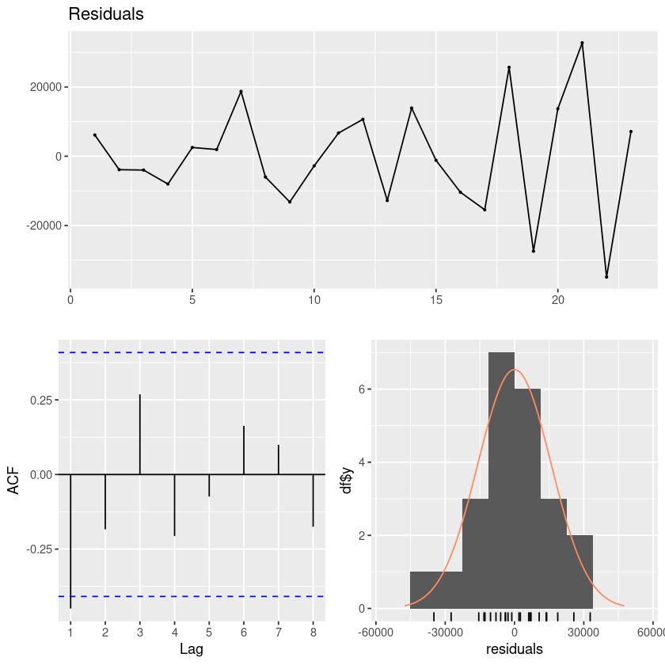

```r
Training$UGSlag1=lag(Training$UGS,1)
Training$NUGVlag1=lag(Training$NUGV,1)
Training$NDGVlag1=lag(Training$NDGV,1)
Training$UGSlag5=lag(Training$UGS,5)
Training$NUGVlag5=lag(Training$NUGV,5)
Training$NDGVlag5=lag(Training$NDGV,5)
Model_7 <- lm(UGS ~ trend+PU+PG+NUGV+NDGV+GNPA+UGSlag1+NUGVlag1+NDGVlag1+UGSlag5+NUGVlag5+NDGVlag5+Quarters_seasonality, Training)
summary(Model_7)
checkresiduals(Model_7$residuals)
```

# 5)Forecasting

```r
Forecast$UGSlag1[1]=Training$UGS[28]
Forecast$NUGVlag1[1]=Training$NUGV[28]
Forecast$NDGVlag1[1]=Training$NDGV[28]
Forecast$UGSlag5[1]=Training$UGS[24]
Forecast$NUGVlag5[1]=Training$NUGV[24]
Forecast$NDGVlag5[1]=Training$NDGV[24]
Forecast[,trend := 29:32 ]
Forecast[,Quarters_seasonality:=as.character(month(Quarters))]



Forecast[1,"UGS"]=as.numeric(predict(Model_7,newdata=Forecast[1,]))
Forecast$UGSlag1[2]=as.numeric(Forecast[1,"UGS"])

Forecast[2,"UGS"]=predict(Model_7,newdata=Forecast[2,])
Forecast$UGSlag1[3]=as.numeric(Forecast[2,"UGS"])

Forecast[3,"UGS"]=predict(Model_7,newdata=Forecast[3,])
Forecast$UGSlag1[4]=as.numeric(Forecast[3,"UGS"])

Forecast[4,"UGS"]=predict(Model_7,newdata=Forecast[4,])
Forecast[,"UGS"]
```

A data.table: 4 × 1

| UGS <dbl> |
| --- |
| 682684.6 |
| 867247.4 |
| 985937.5 |
| 835216.1 |

# 6)Conclusion

The aim of this homework was to assess UGS data in terms of numerous independent variables and create a regression model that could be utilized for forecasting. I added trend, seasonality, variables and lagged variables respectively to the models. Finally, my choosen model was the model which covered all those.